# Reproducible Research: Peer Assessment 1

### Imputing missing values

Note that there are a number of days/intervals where there are missing values (coded as 𝙽𝙰). The presence of missing days may introduce bias into some calculations or summaries of the data.

1. Calculate and report the total number of missing values in the dataset (i.e. the total number of rows with 𝙽𝙰s)

```r
length(data$steps[is.na(data$steps)])
```

```
## [1] 2304
```

2. Devise a strategy for filling in all of the missing values in the dataset. The strategy does not need to be sophisticated. For example, you could use the mean/median for that day, or the mean for that 5-minute interval, etc.

```r
replaceNasWithAvg <-function(x){
  output <- x
  for (lRow in 1:nrow(x)) {
    if (is.na(x[lRow,1])){
      intrvl <- x[lRow,3]
      avgStepsOfInterval <-  averageDailyActivity$steps[averageDailyActivity$interval == intrvl]
      output[lRow,1] <-  avgStepsOfInterval
    }
  }
  output
}
```

3. Create a new dataset that is equal to the original dataset but with the missing data filled in.

```r
imputedData <- replaceNasWithAvg(data)
length(imputedData$steps[is.na(imputedData$steps)])
```

```
## [1] 0
```

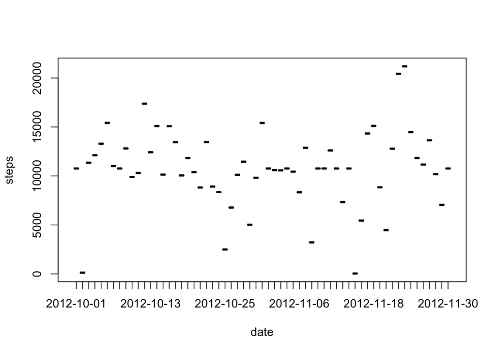

```r
I_totalStepsPerDay <- aggregate(steps ~ date, imputedData, sum)
plot(I_totalStepsPerDay)
```

```r
mean(imputedData[,"steps"]) - mean(data[,"steps"], na.rm = T )
```

```
## [1] 0
```

```r
mean(I_totalStepsPerDay[,"steps"]) - mean(totalStepsPerDay[,"steps"], na.rm = T)
```

```
## [1] 0
```

```r
summary(totalStepsPerDay)
```

```
##          date        steps
##  2012-10-02: 1   Min.   :   41
##  2012-10-03: 1   1st Qu.: 8841
##  2012-10-04: 1   Median :10765
##  2012-10-05: 1   Mean   :10766
##  2012-10-06: 1   3rd Qu.:13294
##  2012-10-07: 1   Max.   :21194
##  (Other)   :47
```

```r
summary(I_totalStepsPerDay)
```

```
##          date        steps
##  2012-10-01: 1   Min.   :   41
##  2012-10-02: 1   1st Qu.: 9819
##  2012-10-03: 1   Median :10766
##  2012-10-04: 1   Mean   :10766
##  2012-10-05: 1   3rd Qu.:12811
##  2012-10-06: 1   Max.   :21194
##  (Other)   :55
```

### Are there differences in activity patterns between weekdays and weekends?

For this part the 𝚠𝚎𝚎𝚔𝚍𝚊𝚢𝚜() function may be of some help here. Use the dataset with the filled-in missing values for this part.

1. Create a new factor variable in the dataset with two levels – “weekday” and “weekend” indicating whether a given date is a weekday or weekend day.

```r
imputedData <- cbind(imputedData[1:3], "day" = NA)
imputedData$day <- weekdays(as.Date(imputedData$date))
imputedData$day[imputedData$day == "Saturday"] <- "weekend"
imputedData$day[imputedData$day == "Sunday"] <- "weekend"
imputedData$day[imputedData$day != "weekend"] <- "weekday"
```

2. Make a panel plot containing a time series plot (i.e. 𝚝𝚢𝚙𝚎l= “𝚕”) of the 5-minute interval (x-axis) and the average number of steps taken, averaged across all weekday days or weekend days (y-axis). See the README file in the GitHub repository to see an example of what this plot should look like using simulated data.

[figure not shown]

```r
averageActivity_Weekday <- imputedData[imputedData$day == "weekday",]
averageActivity_Weekday <- aggregate(steps ~ interval, averageActivity_Weekday, mean)
averageActivity_Weekend <- imputedData[imputedData$day == "weekend",]
averageActivity_Weekend <- aggregate(steps ~ interval, averageActivity_Weekend, mean)
par(mfrow=c(2,1))
par(mar = c(0,0,0,0), oma = c( 4, 4, 2, 0.5))
plot(averageActivity_Weekend, type="l", xaxt="n")
plot(averageActivity_Weekday, type="l")
mtext("Intervalic Activity: Weekday vs. Weekend", side = 3, outer = TRUE, line = 1)
mtext("Steps", side =2, outer = TRUE, line  = 3)
mtext("Interval", side = 1, outer = TRUE, line = 3)
mtext("Weekday Activity", side = 3, outer = FALSE, line = 8, adj = 0)
mtext("Weekend Activity", side = 3, outer = FALSE, line = -2, adj = 0)
```